# Modeling Wage Inequality and Endogenous Growth

## Matt Daniels

### April 16 2019

## Can an endogenous growth model with O-Ring production account for rising wage inequality?

- Here I will present a "simple" model in which monopolistically competitive firms invest in research to improve their productivity, similar to Jones and Kim (2014)
- New technology is modeled as the result of O-ring cooperation among skilled innovators
- Simulation results (VERY rough) suggest:
  - Model generates the familiar fat tail in firm productivity and wages
  - Skill complementarities can drive a modest increase in inequality for some range of increases in skill
  - But overall unlikely to explain the increase in top inequality

## Motivation: Rising Inequality

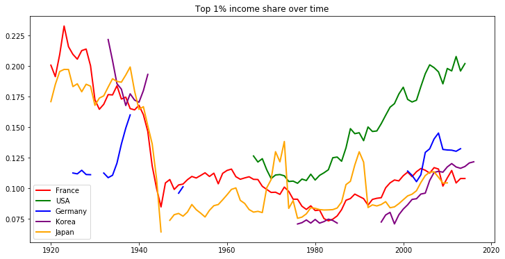

## Motivation: Pareto income (and wages)

$$F(x)=1-(\frac{x_m}{x})^\alpha \quad for \quad x \in [x_m,\infty) \quad and \quad x_m,\alpha>0$$

- Pareto (1896) noted that the top portion of of income distribution follows such a power law
- At the top of the distribution, inequality is "fractal":
  - Ratio of top 1% to top 10% incomes is the same as that between top 0.1% and 1%
  - In recent years the Pareto parameter has been decreasing, yielding greater inequality
- O-Ring type models are known to produce Pareto distributions

## Motivation: Rising college wage premium

- From 1979 to 2016 the percent of workers with a 4-year degree rose from 23 to 40 percent
- Relative wage for college educated went from 134 percent to 168 percent
- College educated workers disproportionately engage in knowledge work
  - And this work tends to emphasize teams and co-location
  - Geographically, skilled workers cluster and recieve higher wages
- I model productivity gain as the output of knowledge work
  - Similar to much of the endogenous growth literature

# Related literature: Endogenous growth

- Beginning with Romer (1986) a class of models has viewed R&D as a deliberate process to develop technology and reap monopolistic profits from its use
- Jones and Kim (2014) demonstrate that an endogenous growth model could generate a Pareto distribution of top incomes
  - Schumpeterian growth model in which entrepreneurial effort lowers the marginal cost of the entrepreneur's variety
  - Growth in productivity of the entrepreneur follows a geometric random walk
  - Also demonstrated that labor income (broadly defined) is a large part of the story of rising inequality in the data

## Additional literature review

Data On inequality

- Luttmer (2007) obtains a Pareto distribution in firm size through random growth
- Empirics on Pareto Distribution: Piketty and Saez (2003), Piketty and Zucman (2014), Piketty et al. (2014), Jones (2015)
- Guvenen et al. (2015) use social security data to examine income shocks in the labor force

Models that look at macro/policy implications

- Maliar et al. (2005) look at the business cycle implications of initial wealth disparity in a representative consumer model
- Li and Sarte (2004) study progressive taxation in an economy where agents have different discount rates
- Garcia-Penalosa and Turnovsky (2008, 2015) explore the implications of varying initial capital endowments on a small macro model
- Chatterjee and Turnovsky (2012) include public capital in macroeconomic model with wealth inequality
- Dosi (2010, 2016) use agent based models to explore dynamics of inequality

## Select process known to generate Pareto distributions

### Benhabib and Bisin, 2017

- Talent: An exponential distribution in talent $f_s(s)=pe^{-ps}$ combined with exponential returns to talent $y = e^{gs}$
- Schooling: Marginal cost of schooling exponentially distributed then so is human capital, so earnings are Pareto
- Span of control: Managers of skill s (uniformly distributed) hire agents to produce with function $f(n,s) = sn^\alpha$
- Assortative matching: O-Ring theory of production due to Kremer (1993) has workers produce "multiplicatively", i.e.: $$E[Y]=k^\alpha(h_1h_2...h_m)mB$$ where $h_i$ is the human capital. Then a uniform distribution over human capital yields a truncated power law distribution (similar to Pareto)
- Hierarchical production: Production organized into levels 1,2,...,I in which technology requires $n_i=\gamma n_{i+1}$

## Model

- Final good is produced via intermediate goods, that are themselves produced through monopolistic competition: $$Y=(\int_{0}^{1}Y_{i}^{\theta}di)^{\frac{1}{\theta}}$$ $$Y_{i}=x_{i}^{\alpha}L_{i}$$ where $x_i$ is the productivity of producer $i$ and $\alpha = (1-\theta)/\theta$
- Firms improve their productivity according to: $$\dot{x_{i}}=An_{i}h_{i}^{n_{i}}x_{i}^{\phi}$$
  - $A$ is the productivity of researchers
  - $\phi$ represents the degree of "fishing out" in the production of technology
  - $h_i \in (0,1)$ is the level of human capital
  - $n_i$ is the number of workers engaged in improving productivity at firm i
- Firms die with constant rate $\delta$

## Model (cont'd)

- Following derivation of Jones and Kim (2014), instantaneous profit in this model is: $$(1-\theta)X_{t}^{\alpha}(\frac{x_{it}}{X_{t}})L_{t}$$ where $X_{t}$ is the mean of firm productivities $x_{it}$
- The wage of production workers is: $$w_t=\theta X_{t}^{\alpha}$$
- Wages for skilled workers engaged in research is determined by firms marginal willingness to pay

## Research production for various skills and team sizes

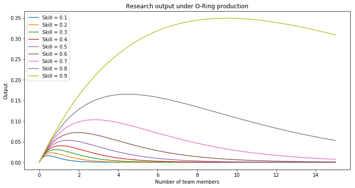

## Simulation set up

### (take everything with a generous helping of salt)

- I've conducted very rough simulations to get a sense of how the model performs
- Some shortcuts and computational issues, so this is **highly preliminary**
  - For instance firms choose team size to maximize growth (rather than profit)
- Setup:
  - 10,000 workers distributed normally in skill (with tails truncated at 0 and 1)
  - 400 firms
  - 1,000 iterations of productivity growth
    - no guarantee that this finds stationary distribution of productivity
  - $\delta = 0.1$
  - $\phi = 0.5$
  - $\theta = 0.66$
  - $A = 0.1$

## Example productivity distribution

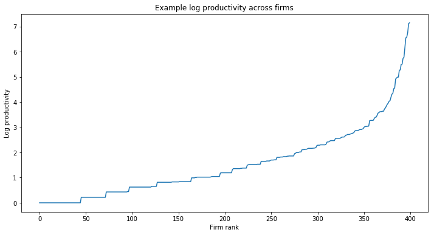

## Example wage distribution

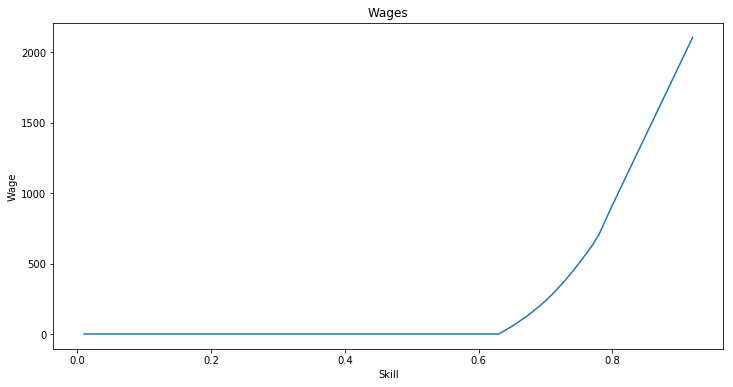

## Increasing average skill raises top and labor incomes

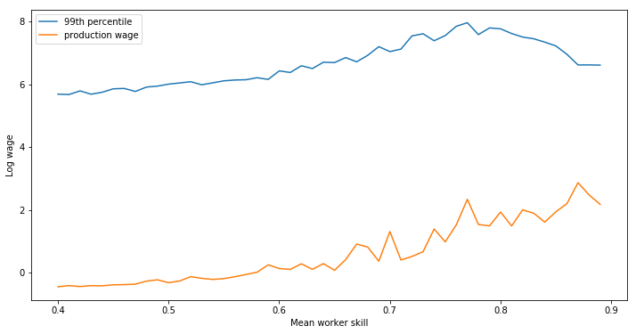

## The 1 percent does slightly better with a more skilled workforce

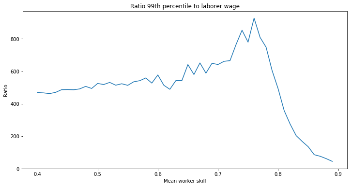

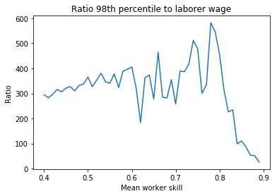

## This effect appears less pronounced looking at just the highest skilled workers

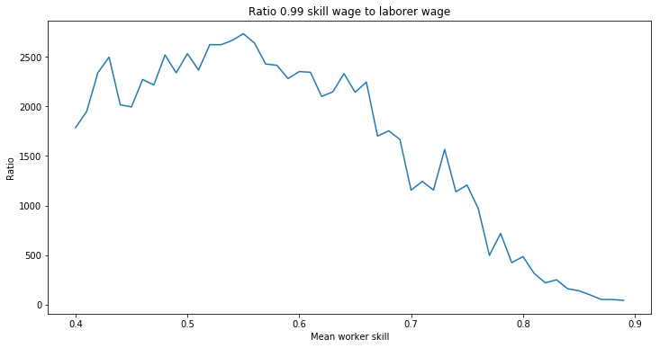

## The 95th percentile also shows a slight increase

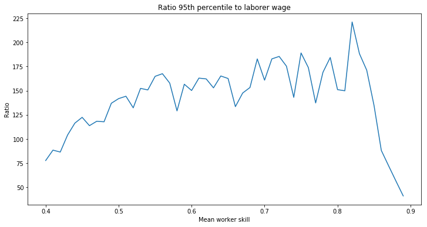

## For the 0.95 skill level the competitive effect appears to dominate

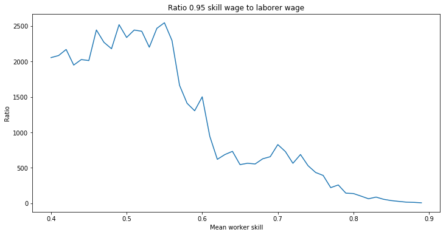

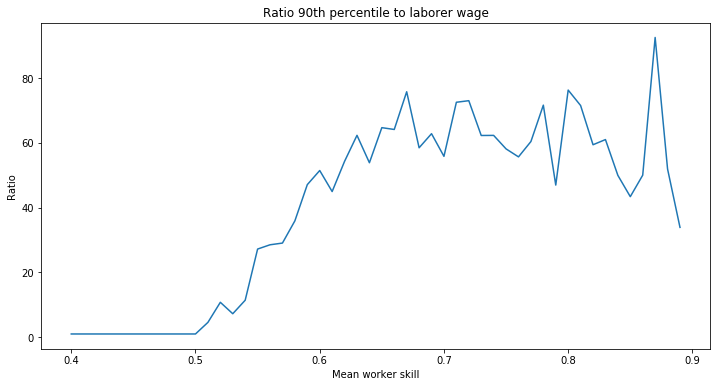